# Neural Network Workbook

Welcome to the Neural Network Workbook. Remember, ideally we would like to use TensorFlow or Keras for Deep Learning as they enable more features. As this class deals with the basics of Machine Learning, we will only use Sklearn.

```python
import numpy as np
import pandas as pd

from matplotlib import pyplot as plt
%matplotlib inline

import seaborn as sns
sns.set_style('darkgrid')

%matplotlib notebook
```

Let’s start with creating a data set with noise.

```python
x = np.linspace(0, 2*np.pi, 300)
# noise
np.random.seed(321)
noise = np.random.normal(0, .5, 300)
# target variable
y = np.sin(x) + noise
```

We will plot the x and y to see how the data set looks.

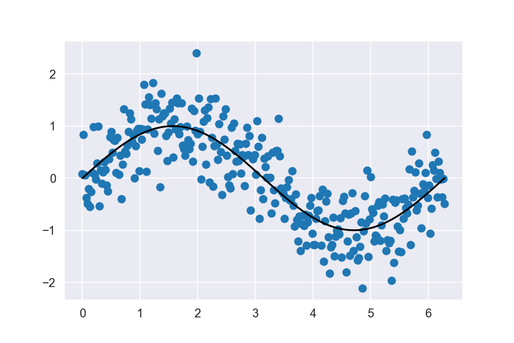

```python
fig = plt.figure(figsize=[6,4])
ax = plt.subplot(111)

# Scatterplot of x and y
ax.scatter(x, y)

# Overlay the sine wave
ax.plot(x, np.sin(x), color='k')

plt.show()
```

We are now going to split our data set into train and test sets.

```python
from sklearn.model_selection import train_test_split
```

```python
X_train, X_test, y_train, y_test = train_test_split(x, y, test_size=0.3)
```

## MLP Regressor

Now we import the MLPRegressor from sklearn.neural network library.

```python
from sklearn.neural_network import MLPRegressor
```

```python
mlp = MLPRegressor(random_state=5)
```

```python
mlp.fit(X_train.reshape(-1, 1), y_train)
```

```
MLPRegressor(random_state=5)
```

Neural networks work with special shapes. Don’t forget to reshape your input data set.

```python
y_pred = mlp.predict(X_test.reshape(-1, 1))
```

Let’s see how our first prediction looks like.

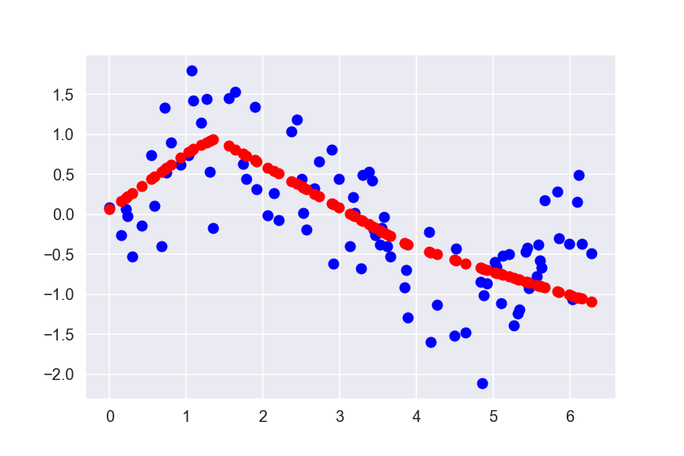

```python
fig = plt.figure(figsize=[6,4])
ax = plt.subplot(111)


# Overlay the sine wave
ax.scatter(X_test, y_test, color='b')
# Overlay the sine wave
ax.scatter(X_test, y_pred, color='r')

plt.show()
```

We can do better, but how? ### Changing Neuron Number Let’s try changing the neuron number.

```python
mlp2 = MLPRegressor(random_state=5, hidden_layer_sizes=[10])
```

```python
mlp2.fit(X_train.reshape(-1, 1), y_train)
```

```
MLPRegressor(hidden_layer_sizes=[10], random_state=5)
```

```python
y_pred2 = mlp2.predict(X_test.reshape(-1, 1))
```

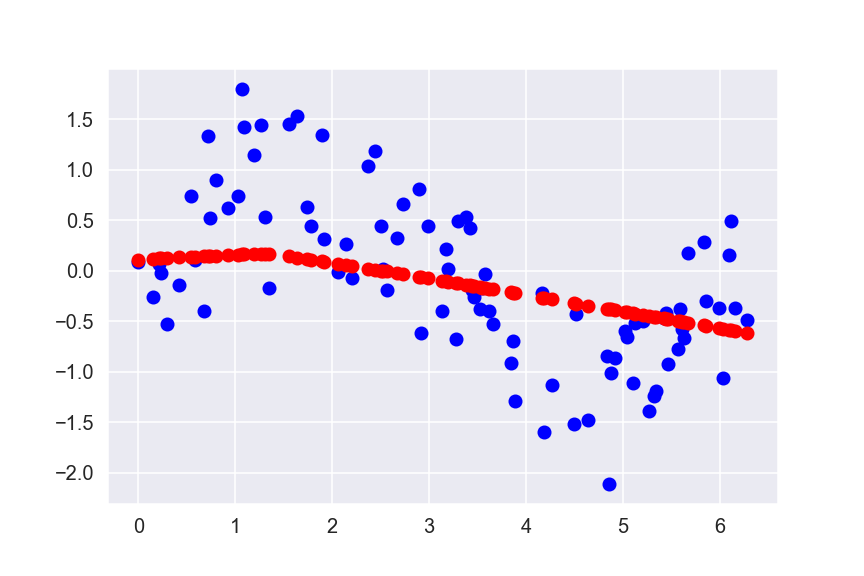

```python
fig = plt.figure(figsize=[6,4])
ax = plt.subplot(111)


# Overlay the sine wave
ax.scatter(X_test, y_test, color='b')
# Overlay the sine wave
ax.scatter(X_test, y_pred2, color='r')

plt.show()
```

We certainly didn’t do any better. Let’s increate the neuron size above the default value.

```python
mlp3 = MLPRegressor(random_state=5, hidden_layer_sizes=[200])
```

```python
mlp3.fit(X_train.reshape(-1, 1), y_train)
```

```
MLPRegressor(hidden_layer_sizes=[200], random_state=5)
```

```python
y_pred3 = mlp3.predict(X_test.reshape(-1, 1))
```

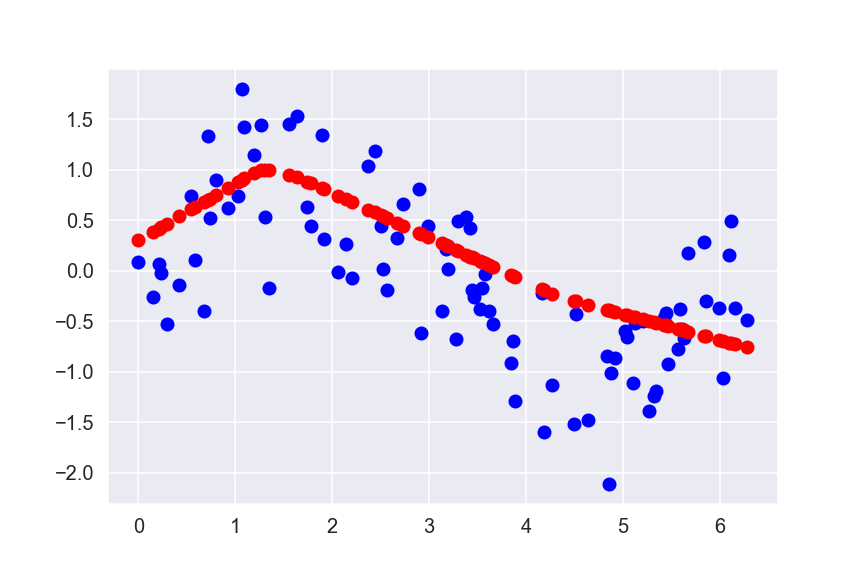

```python
fig = plt.figure(figsize=[6,4])
ax = plt.subplot(111)


# Overlay the sine wave
ax.scatter(X_test, y_test, color='b')
# Overlay the sine wave
ax.scatter(X_test, y_pred3, color='r')

plt.show()
```

```python
mlp4 = MLPRegressor(random_state=5, hidden_layer_sizes=[100,100])
```

```python
mlp4.fit(X_train.reshape(-1, 1), y_train)
```

```
MLPRegressor(hidden_layer_sizes=[100, 100], random_state=5)
```

```python
mlp4.n_layers_
```

```
4
```

We have only added one more layer, why are there 4 layers?

```python
y_pred4 = mlp4.predict(X_test.reshape(-1, 1))
```

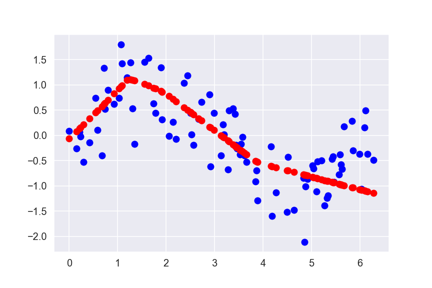

```python
fig = plt.figure(figsize=[6,4])
ax = plt.subplot(111)


# Overlay the sine wave
ax.scatter(X_test, y_test, color='b')
# Overlay the sine wave
ax.scatter(X_test, y_pred4, color='r')

plt.show()
```

The tail looks better, will adding even more layers help?

```python
mlp5 = MLPRegressor(random_state=5, hidden_layer_sizes=[100,80,60,40,20])
```

```python
mlp5.fit(X_train.reshape(-1, 1), y_train)
```

```
MLPRegressor(hidden_layer_sizes=[100, 80, 60, 40, 20], random_state=5)
```

```python
mlp5.n_layers_
```

```
7
```

```python
y_pred5 = mlp5.predict(X_test.reshape(-1, 1))
```

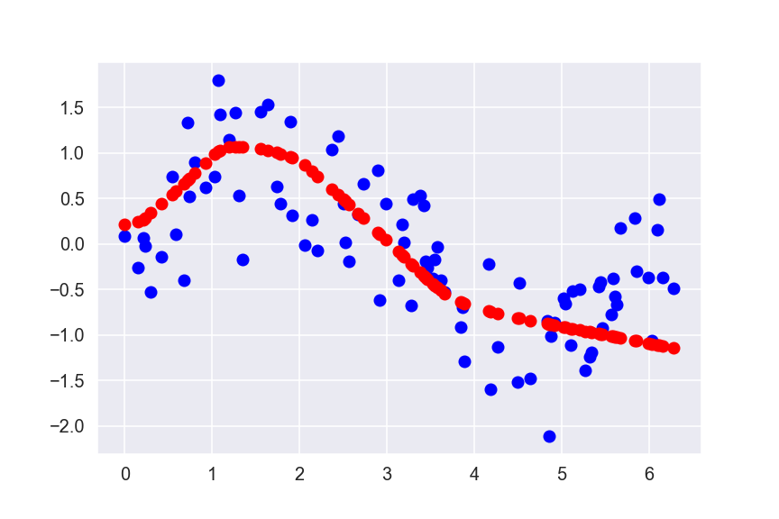

```python
fig = plt.figure(figsize=[6,4])
ax = plt.subplot(111)


# Overlay the sine wave
ax.scatter(X_test, y_test, color='b')
# Overlay the sine wave
ax.scatter(X_test, y_pred5, color='r')

plt.show()
```

This doesn’t seem like a monumental gain. ### Changing Activation Function We can try the way the neurons are activated.

```python
mlp6 = MLPRegressor(random_state=5, activation='tanh')
```

```python
mlp6.fit(X_train.reshape(-1, 1), y_train)
```

```
MLPRegressor(activation='tanh', random_state=5)
```

```python
y_pred6 = mlp6.predict(X_test.reshape(-1, 1))
```

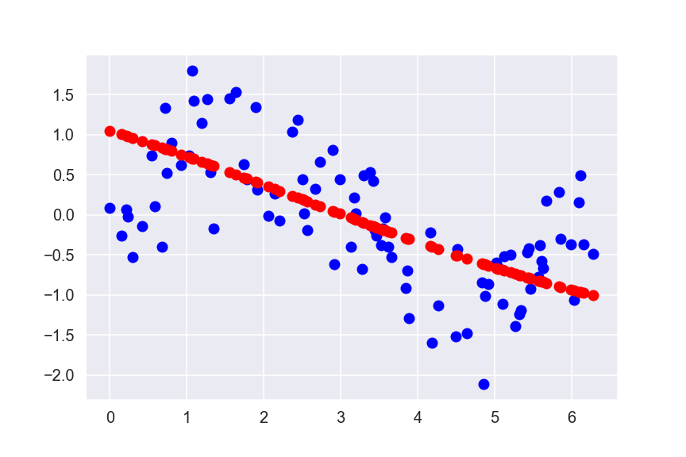

```python
fig = plt.figure(figsize=[6,4])
ax = plt.subplot(111)


# Overlay the sine wave
ax.scatter(X_test, y_test, color='b')
# Overlay the sine wave
ax.scatter(X_test, y_pred6, color='r')

plt.show()
```

```python
mlp7 = MLPRegressor(random_state=5, activation='tanh',  hidden_layer_sizes=[100,80,60,40,20])
mlp7.fit(X_train.reshape(-1, 1), y_train)
y_pred7 = mlp7.predict(X_test.reshape(-1, 1))
```

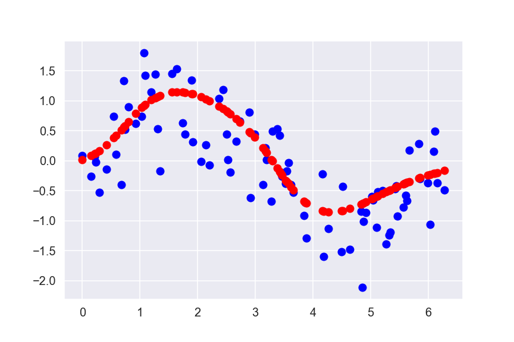

```python
fig = plt.figure(figsize=[6,4])
ax = plt.subplot(111)


# Overlay the sine wave
ax.scatter(X_test, y_test, color='b')
# Overlay the sine wave
ax.scatter(X_test, y_pred7, color='r')

plt.show()
```

```python
mlp8 = MLPRegressor(random_state=5, alpha=0.1)
mlp8.fit(X_train.reshape(-1, 1), y_train)
y_pred8 = mlp8.predict(X_test.reshape(-1, 1))
```

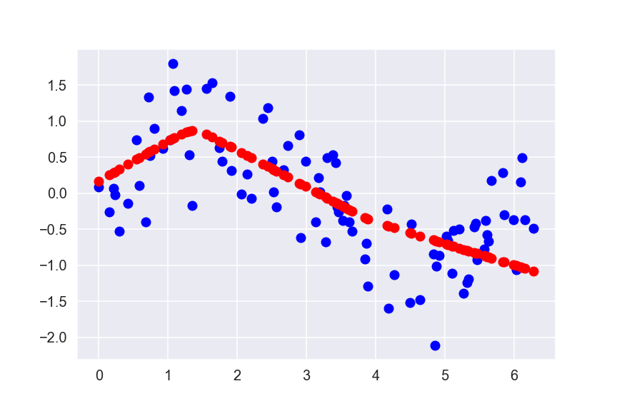

```python
fig = plt.figure(figsize=[6,4])
ax = plt.subplot(111)


# Overlay the sine wave
ax.scatter(X_test, y_test, color='b')
# Overlay the sine wave
ax.scatter(X_test, y_pred8, color='r')

plt.show()
```

```python
mlp9 = MLPRegressor(random_state=5, activation='tanh',  hidden_layer_sizes=[100,80,60,40,20], alpha = 0.1)
mlp9.fit(X_train.reshape(-1, 1), y_train)
y_pred9 = mlp9.predict(X_test.reshape(-1, 1))
```

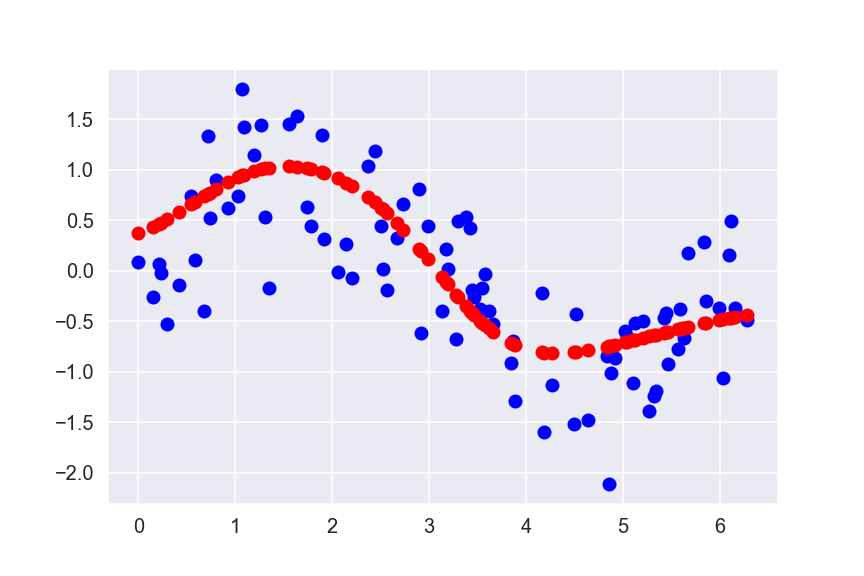

```python
fig = plt.figure(figsize=[6,4])
ax = plt.subplot(111)


# Overlay the sine wave
ax.scatter(X_test, y_test, color='b')
# Overlay the sine wave
ax.scatter(X_test, y_pred9, color='r')

plt.show()
```

Seems like a better fit, but to be sure we need to quantify the performance. ### Evaluation an MLP Regressor Remember how we used to evaluate a regressor?

```python
from sklearn.metrics import mean_squared_error as mse
```

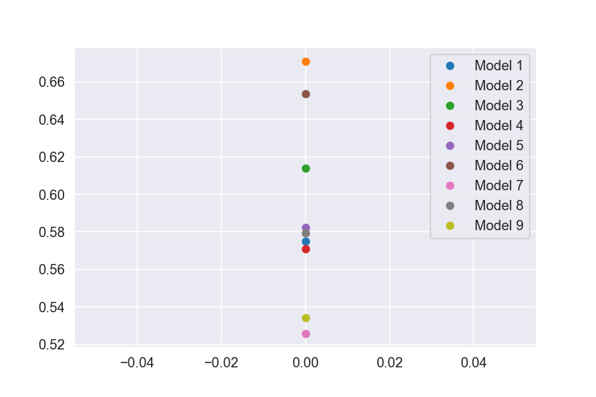

```python
fig = plt.figure(figsize=[6,4])
ax = plt.subplot(111)

# Overlay the sine wave
ax.plot(mse(y_test,y_pred,squared=False), '.', markersize=10, label='Model 1')
ax.plot(mse(y_test,y_pred2,squared=False), '.', markersize=10, label='Model 2')
ax.plot(mse(y_test,y_pred3,squared=False), '.', markersize=10, label='Model 3')
ax.plot(mse(y_test,y_pred4,squared=False), '.', markersize=10, label='Model 4')
ax.plot(mse(y_test,y_pred5,squared=False), '.', markersize=10, label='Model 5')
ax.plot(mse(y_test,y_pred6,squared=False), '.', markersize=10, label='Model 6')
ax.plot(mse(y_test,y_pred7,squared=False), '.', markersize=10, label='Model 7')
ax.plot(mse(y_test,y_pred8,squared=False), '.', markersize=10, label='Model 8')
ax.plot(mse(y_test,y_pred9,squared=False), '.', markersize=10, label='Model 9')

ax.legend()
plt.show()
```

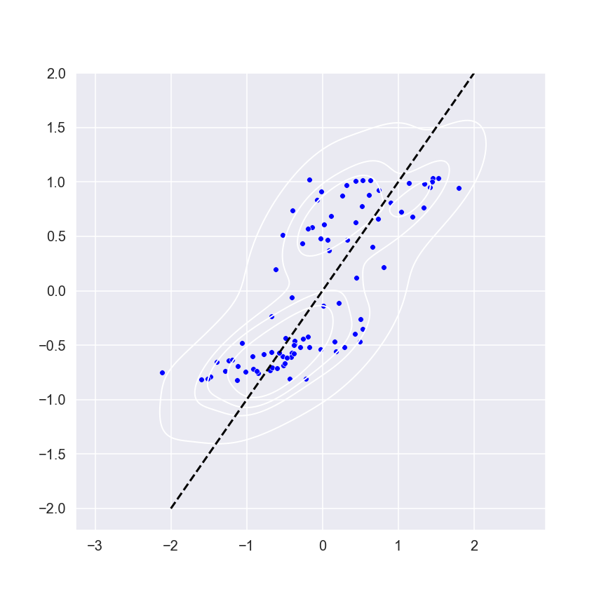

```python
f, ax = plt.subplots(figsize=(6, 6))
sns.scatterplot(x=y_test, y=y_pred9, s=15, color="b")
sns.kdeplot(x=y_test, y=y_pred9, levels=5, color="w", linewidths=1)
ax.plot(np.linspace(-2,2,100),np.linspace(-2,2,100),'k--')
```

There are other ways we can evaluate the performance.

## MLP Classifier

Now, let’s look at how we can use Multi-layer perceptrons for classification problems. First we will recreate that difficult data set using make_moons.

```python
from sklearn.datasets import make_moons
```

```python
X, y = make_moons(n_samples=300, noise=0.2, random_state=0)
```

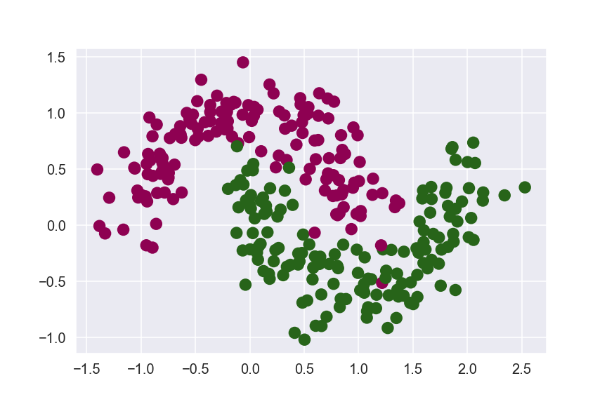

```python
fig = plt.figure(figsize=[6,4])
ax = plt.subplot(111)

ax.scatter(X[:,0], X[:,1], c=y, cmap='PiYG', s=60)
```

Import the MLPClassifier library.

```python
from sklearn.neural_network import MLPClassifier
```

Now, let’s separate the data set into training and test sets.

```python
X_train, X_test, y_train, y_test = train_test_split(X, y, test_size=0.3)
```

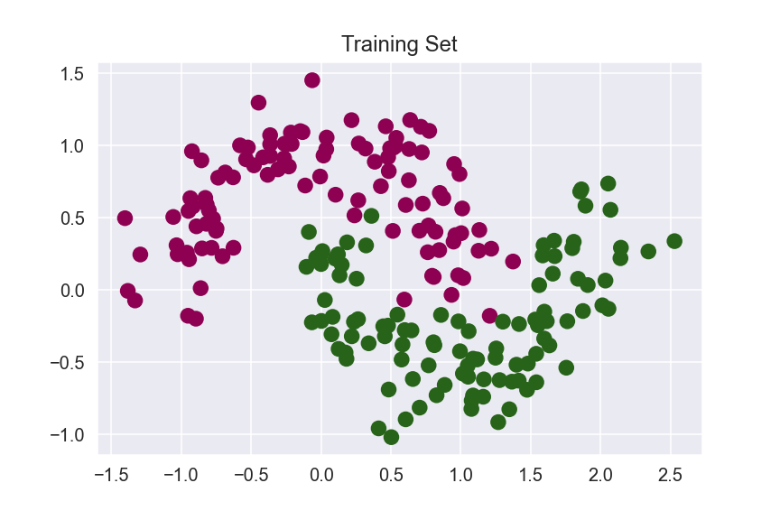

```python
fig = plt.figure(figsize=[6,4])
ax = plt.subplot(111)

ax.scatter(X_train[:,0], X_train[:,1], c=y_train, cmap='PiYG', s=60)
plt.title('Training Set')
```

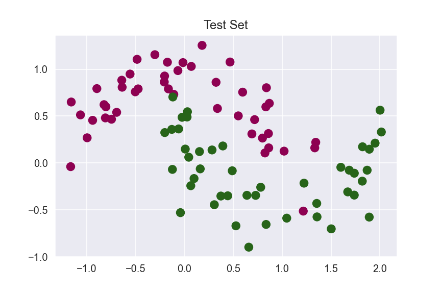

```python
fig = plt.figure(figsize=[6,4])
ax = plt.subplot(111)

ax.scatter(X_test[:,0], X_test[:,1], c=y_test, cmap='PiYG', s=60)
plt.title('Test Set')
```

Create the MLPClassifier.

```python
mlp = MLPClassifier(random_state=5)
```

```python
mlp.fit(X_train, y_train)
```

```
MLPClassifier(random_state=5)
```

```python
y_pred = mlp.predict(X_test)
```

```python
y_test
```

```
array([1, 1, 0, 1, 1, 1, 0, 1, 0, 0, 0, 0, 0, 1, 1, 0, 1, 1, 1, 1, 0, 0,
       1, 1, 1, 1, 0, 1, 0, 1, 0, 1, 0, 0, 1, 1, 1, 1, 1, 0, 0, 0, 0, 0,
       1, 0, 1, 0, 0, 0, 1, 1, 1, 0, 1, 0, 1, 0, 0, 0, 0, 0, 1, 1, 0, 1,
       1, 1, 0, 0, 1, 1, 1, 0, 0, 1, 0, 1, 0, 1, 1, 0, 1, 0, 1, 0, 0, 0,
       0, 0])
```

```python
y_pred
```

```
array([1, 1, 0, 1, 1, 1, 0, 1, 0, 0, 0, 0, 0, 1, 1, 0, 1, 1, 1, 1, 0, 0,
       1, 1, 1, 1, 0, 1, 0, 0, 0, 0, 0, 1, 1, 0, 1, 1, 1, 1, 0, 0, 0, 0,
       1, 0, 1, 0, 1, 0, 1, 1, 0, 0, 1, 0, 1, 0, 1, 0, 0, 0, 1, 1, 0, 0,
       0, 1, 0, 0, 1, 1, 0, 1, 0, 1, 0, 1, 1, 0, 0, 0, 0, 0, 1, 1, 0, 0,
       0, 0])
```

Let’s see how the predictions look like.

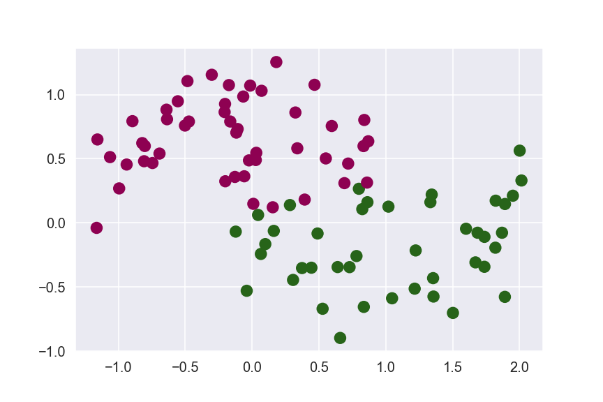

```python
fig = plt.figure(figsize=[6,4])
ax = plt.subplot(111)

ax.scatter(X_test[:,0], X_test[:,1], c=y_pred, cmap='PiYG', s=60)
```

```python
mlp.hidden_layer_sizes
```

```
(100,)
```

There are subtle differences. ### Changing Neuron Number Let’s see if changing the neuron number will help.

```python
mlp2 = MLPClassifier(random_state=5, hidden_layer_sizes=[10])
```

```python
mlp2.fit(X_train, y_train)
```

```
MLPClassifier(hidden_layer_sizes=[10], random_state=5)
```

```python
y_pred2 = mlp2.predict(X_test)
```

```python
fig = plt.figure(figsize=[6,4])
ax = plt.subplot(111)

ax.scatter(X_test[:,0], X_test[:,1], c=y_pred2, cmap='PiYG', s=60)
```

[output not shown]

Still, there are some differences. ### Changing Layer Number Let’s see if adding layers will help.

```python
mlp3 = MLPClassifier(random_state=5, hidden_layer_sizes=[10,10])
```

```python
mlp3.fit(X_train, y_train)
```

```
MLPClassifier(hidden_layer_sizes=[10, 10], random_state=5)
```

```python
y_pred3 = mlp3.predict(X_test)
```

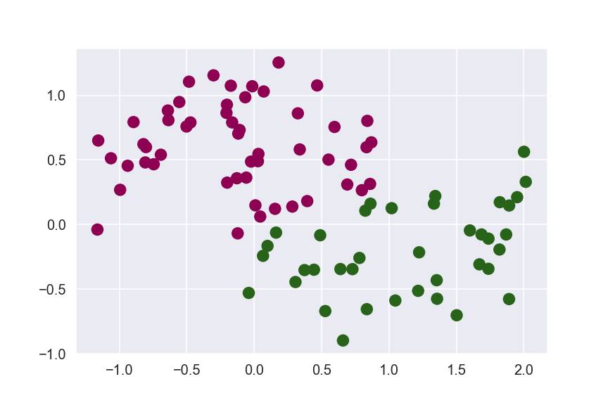

```python
fig = plt.figure(figsize=[6,4])
ax = plt.subplot(111)

ax.scatter(X_test[:,0], X_test[:,1], c=y_pred3, cmap='PiYG', s=60)
```

### Changing Activation Function

Let’s see how to change the activation function.

```python
mlp4 = MLPClassifier(random_state=5, hidden_layer_sizes=[10], activation='tanh')
```

```python
mlp4.fit(X_train, y_train)
```

```
MLPClassifier(activation='tanh', hidden_layer_sizes=[10], random_state=5)
```

```python
y_pred4 = mlp4.predict(X_test)
```

```python
fig = plt.figure(figsize=[6,4])
ax = plt.subplot(111)

ax.scatter(X_test[:,0], X_test[:,1], c=y_pred4, cmap='PiYG', s=60)
```

[output not shown]

```python
mlp.alpha
```

```
0.0001
```

### Changing Learning Rate/Regularization

```python
mlp5 = MLPClassifier(random_state=5, hidden_layer_sizes=[10], alpha=0.01)
```

```python
mlp5.fit(X_train, y_train)
```

```
MLPClassifier(alpha=0.01, hidden_layer_sizes=[10], random_state=5)
```

```python
y_pred5 = mlp5.predict(X_test)
```

```python
fig = plt.figure(figsize=[6,4])
ax = plt.subplot(111)

ax.scatter(X_test[:,0], X_test[:,1], c=y_pred5, cmap='PiYG', s=60)
```

[output not shown]

It is hard to evaluate by eye. ### Evaluation an MLP Classifier Remember how we used to evaluate a classifier?

[output not shown]

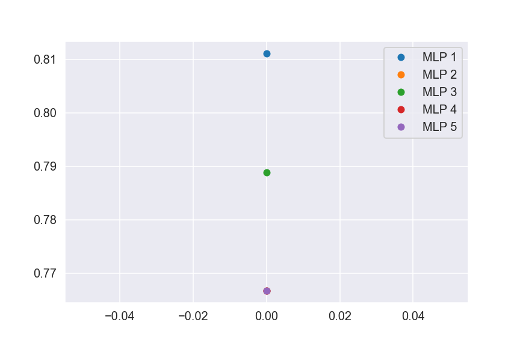

```python
fig = plt.figure(figsize=[6,4])
ax = plt.subplot(111)

ax.plot(mlp.score(X_test,y_test),'.', markersize=10, label='MLP 1')
ax.plot(mlp2.score(X_test,y_test),'.', markersize=10, label='MLP 2')
ax.plot(mlp3.score(X_test,y_test),'.', markersize=10, label='MLP 3')
ax.plot(mlp4.score(X_test,y_test),'.', markersize=10, label='MLP 4')
ax.plot(mlp5.score(X_test,y_test),'.', markersize=10, label='MLP 5')

ax.legend()
```

```python
from sklearn.metrics import silhouette_score
```

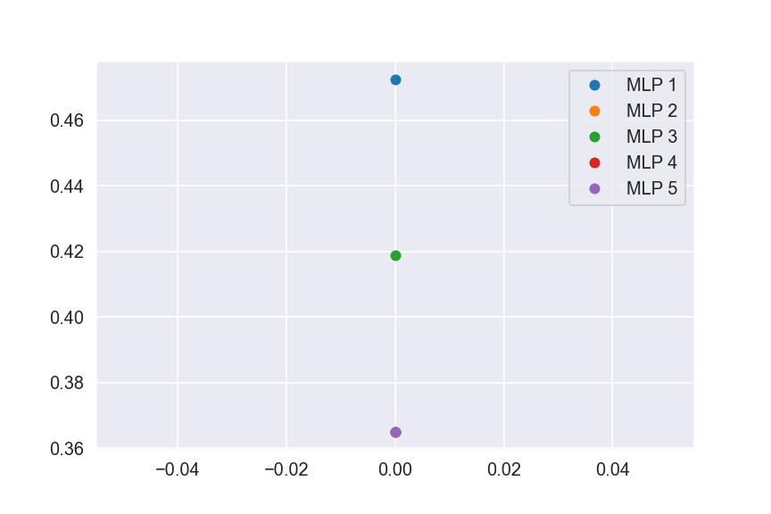

```python
fig = plt.figure(figsize=[6,4])
ax = plt.subplot(111)

ax.plot(silhouette_score(y_test.reshape(-1, 1),y_pred),'.', markersize=10, label='MLP 1')
ax.plot(silhouette_score(y_test.reshape(-1, 1),y_pred2),'.', markersize=10, label='MLP 2')
ax.plot(silhouette_score(y_test.reshape(-1, 1),y_pred3),'.', markersize=10, label='MLP 3')
ax.plot(silhouette_score(y_test.reshape(-1, 1),y_pred4),'.', markersize=10, label='MLP 4')
ax.plot(silhouette_score(y_test.reshape(-1, 1),y_pred5),'.', markersize=10, label='MLP 5')

ax.legend()
```

👏 Congratulations, you have completed the Neural Network Workbook!